# Terrorism: Patterns, Actors, and Underlying Factors

Author

Hengyi Xing, Section 04, hengyix; Sienna Wang, Section 01, SiennaWang12

Published

December 5, 2024

Global instability and political polarization have been increasing, with terrorism affecting the globe. What factors contribute to the higher frequency and intensity of terrorist attacks in certain regions? This research analyzes the countries most affected by terrorism between 2000 and 2020, identifies the primary groups responsible, and explores their motives. The main dataset is from [Global Terrorism Database (GTD)](https://www.start.umd.edu/gtd/).

## 1. Geographical Distribution

To analyze the geographical distribution of terrorist activities, we used two metrics: attack count and casualties. Attack count identifies hotspots, with total casualties adding depth beyond attack frequency.

We used GeoPandas to create interactive choropleth maps in a Shiny app, allowing users to select the desired metric and hover for countries and figures. A time slider was omitted due to the limited number of countries affected each year, making year-by-year maps less meaningful. Instead, users can explore year-specific data in an attached table, defining both year and sorting order.

A drawback of the map is that due to several very high values, other areas appear lighter, making visual differences less noticeable. However, to highlight hotspots, we still chose to display original figures instead of processed results like logarithms.

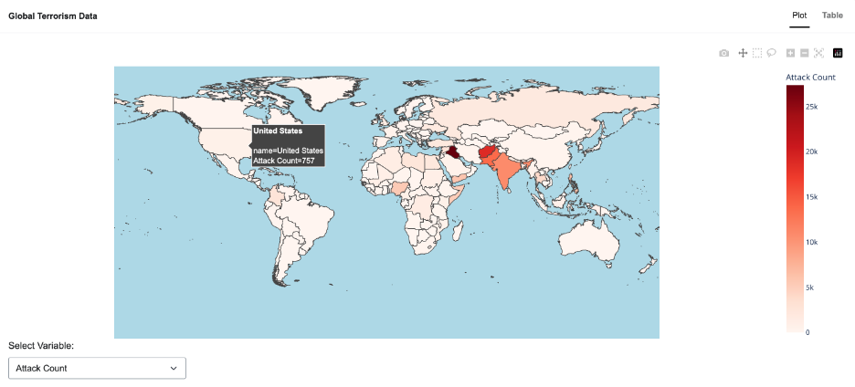

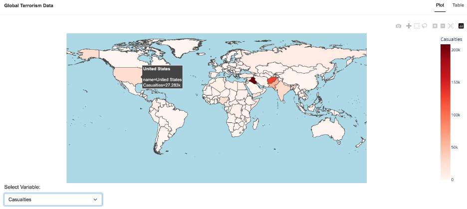

Iraq and South Asia are the most affected regions in terms of both attack count and casualties, indicating severe impacts from terrorism. Additionally, the United States, despite few attacks, shows a high casualty count due to significant events like 9/11.

These maps raise questions about factors contributing to higher attack counts in certain regions. Further research explores links to political systems (democracy levels) and economic development (GDP).

We obtained democracy level data from the [Polity V](https://www.systemicpeace.org/inscrdata.html), averaging scores from 2000-2018 (the latest data available is from 2018). After merging the data, we plotted the correlation between terrorist attacks and democracy scores. One issue we encountered is that over the 20-year period, a large number of countries experienced terrorist attacks, and the number of such incidents was relatively small. Thus, we focused on countries with over 1,000 events to avoid a cluttered chart.

For economic development, we used GDP data from the [World Bank database](https://databank.worldbank.org/indicator/NY.GDP.PCAP.CD/1ff4a498/Popular-Indicators#). We averaged GDP from 2000 to 2020 and merged it with terrorism data, ensuring compatibility by reconciling country names and addressing historical changes (e.g., Yugoslavia). The data was scaled logarithmically to illustrate patterns across countries with large GDP and attack count variations. One limitation is the equal allocation of attack counts from Yugoslavia and Serbia-Montenegro to present-day Serbia and Montenegro, potentially overlooking regional differences. Additionally, using a 20-year average GDP assumes stability over time, oversimplifying economic fluctuations that could affect the observed relationships.

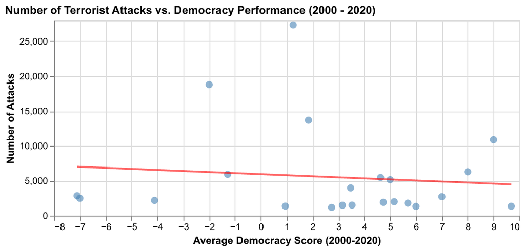

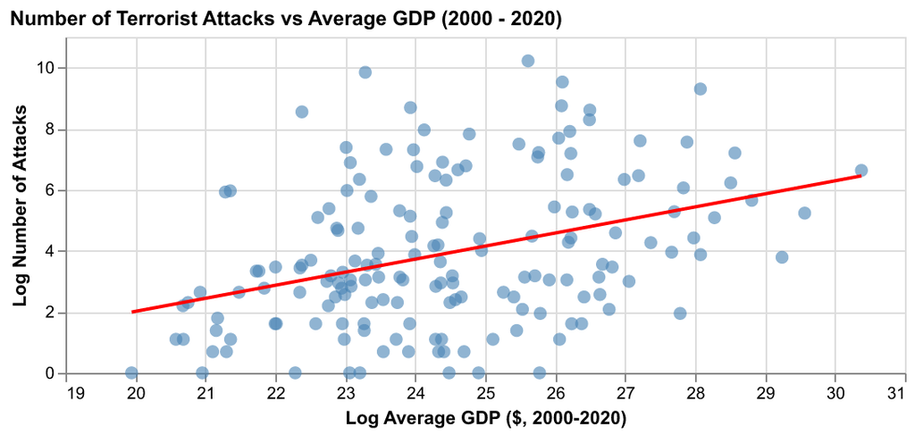

The negative relationship between democracy and terrorist attacks implies that authoritarian countries may be more vulnerable to terrorism. Policymakers should focus on strengthening political stability and addressing grievances in authoritarian regions to reduce the likelihood of terrorism. The positive trend between GDP and terrorist attacks suggests that wealthier countries may be attractive targets for terrorism. This could imply that economically prosperous countries need to enhance their domestic security and counterterrorism strategies.

However, these charts show correlations, not causations. The observed relationships do not imply that lower democracy or higher GDP causes more terrorist attacks. Numerous confounding factors, such as historical conflicts and regional influences, could affect GDP, democracy, and terrorism rates.

## 2. Most Active Groups

Based on the previous maps, we categorized terrorist activities by region and identified most active groups based on the number of attacks, providing insight into regional terrorism dynamics.

We calculated the number of attacks attributed to different groups and their proportion in each region, visualizing the top 10 groups per region using a dynamic bar chart in the Shiny app. It allows users to select different regions and view detailed information by hovering over the bars.

One challenge was that many group names are too long to display in the chart. To address this, we truncated and rotated labels while ensuring the full names are visible in tooltips for clarity. For truncated names resulting in identical labels, we appended unique identifiers, such as “(1)” or “(2)”, to distinguish them effectively. This approach maintains readability while preserving access to full group information.

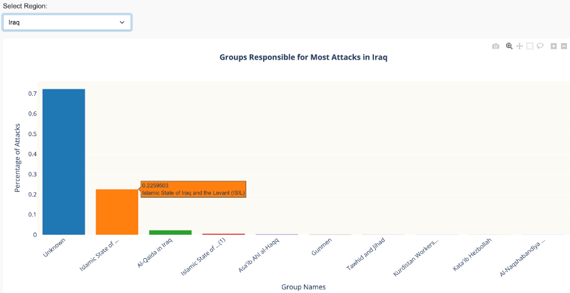

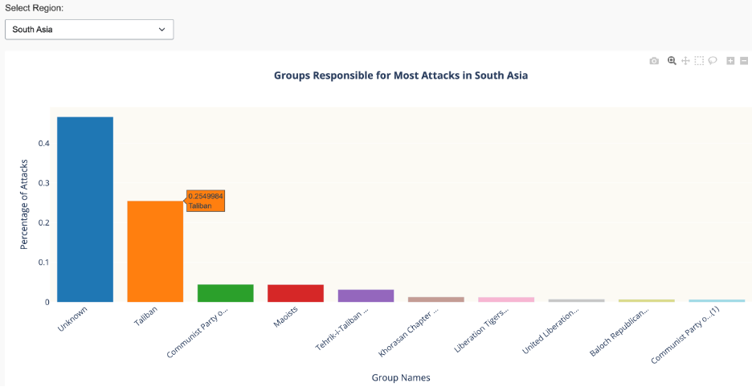

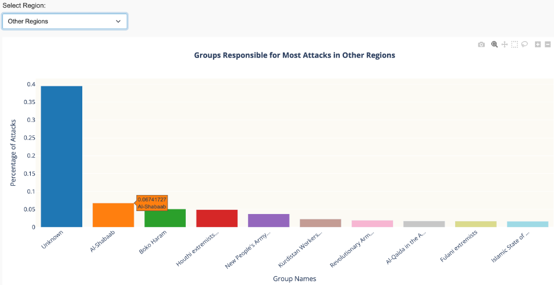

Most terrorist incidents are attributed to unknown entities, and no single identified group is active globally. This aligns with the secretive nature of terrorism, complicating efforts to combat it. However, when focusing on Iraq and South Asia, ISIL and the Taliban stand out respectively.

## 3. The Primary Motivations for Attacks (NLP)

We explored the motivations behind the Taliban and ISIL using TF-IDF to identify key distinguishing words from the `motive` field. This approach captures the relative importance of words within each group compared to the entire dataset, crucial given the repetitive nature of the descriptions.

We began by filtering incidents linked to each group and pre-process the motive texts by removing stop words and irrelevant terms. TF-IDF was then applied to extract the most relevant keywords, visualized through bar charts.

However, TF-IDF may assign low scores to repetitive phrases, diluting the overall results and causing genuinely distinctive words to be overshadowed or omitted. Additionally, incomplete or missing data complicates efforts to capture a comprehensive representation of motives, potentially skewing the insights.

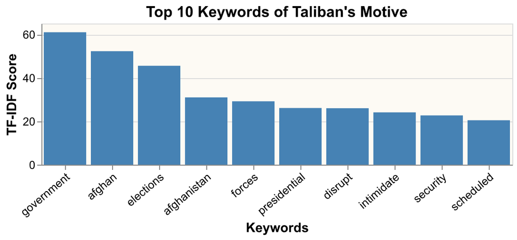

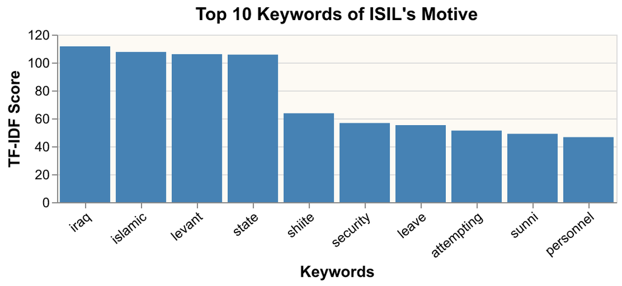

In analyzing the motives of the Taliban, keywords like “government,” “Afghan,” and “elections” suggest their focus on undermining the Afghan government and disrupting elections, aligning with their goal of weakening political stability. ISIL’s motives are reflected in keywords like “Iraq,” “Islamic,” and “Levant,” highlighting their regional focus and aspirations for an Islamic governance structure. Terms like “Sunni” indicate their use of sectarian divisions to extend influence and consolidate control.

This suggests that, for the Taliban, the focus should be on safeguarding government institutions and stabilizing electoral processes to counteract their efforts to disrupt governance. Regarding ISIL, there could be a need for policies that reduce inter-religious tensions and strengthen regional cooperation to contain their influence.

## 4. Directions for Future Work

Future research could delve into nuanced relationships involving regional conflicts and motives, aiming to understand how historical, cultural, and socio-political factors interact to drive terrorism in specific areas. Also, incorporating dynamic, year-on-year changes in GDP, democracy scores, and terror attack frequencies would allow for a more comprehensive understanding of how economic and political fluctuations influence terrorism over time. This approach could reveal patterns of vulnerability linked to economic instability or shifts in governance quality, providing a clearer picture of causality rather than simple correlation.

Moreover, a deeper analysis into the psychology behind group motivations could shed light on the individual and collective drivers of radicalization, including ideological, emotional, and social factors. Understanding the psychological mechanisms that sustain terrorist recruitment and commitment could inform more effective prevention and deradicalization strategies, focusing not just on structural factors but also on the cognitive and emotional dimensions that underpin extremist behavior.